# cv11.R

Marek

2023-04-27

```r
library(latexpdf)
```

# Analyza reziduj a vplyvnych bodov regresie

reziduu je vlastne chyba, ktorej sa dopustime ak skutocne nameranu hodnotu nahradime odhadnutou z modelu. Toto nazyvame klasicke reziidum. Zacneme prikladom Certifikacny urad vykonal 11 nahodnych merani na rovnakych obrabacich strojoch s cielom zistit interval pravidelnej kalibracie. Merala sa odchylka od optimalneho nastavenia (%) a doba prevadzky (v mesiacoch) od poslednej kalibracie. Spocitajte korelacne koeficienty, prelozte vhodny regresny model, analyzujte rezidua, zistite vplyvne body regresie

```r
doba <- c(8, 3, 6, 7, 10, 14, 8, 2, 16, 5, 6)
odchylka <- c(0.15, 0.08, 0.3, 0.25, 0.6, 1.05, 0.9, 0.09, 1.15, 0.35, 0.15)

korelacie <- function(x, y){c('Pearson' = cor(x, y),
                              'Kendall' = cor(x, y, method = 'kendall'),
                              'Spearman' = cor(x, y, method = 'spearman'))}
korelacie(doba, odchylka)
```

```
##   Pearson   Kendall  Spearman
## 0.8772262 0.6355418 0.8100708
```

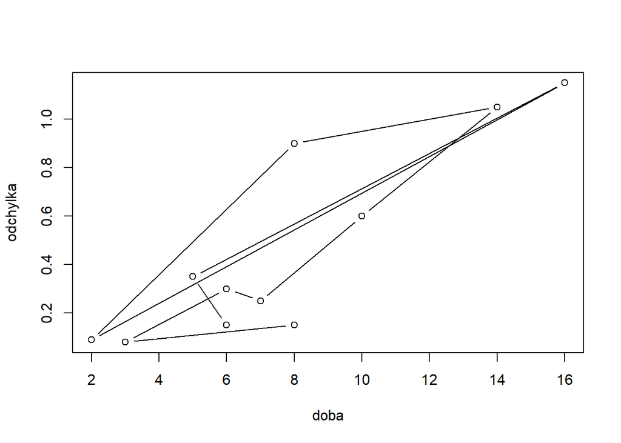

```r
plot(doba, odchylka, type = 'b')
```

```r
m1 <- lm(odchylka~doba)
summary(m1)
```

```
##
## Call:
## lm(formula = odchylka ~ doba)
##
## Residuals:
##      Min       1Q   Median       3Q      Max
## -0.33328 -0.09929  0.00683  0.08672  0.41672
##
## Coefficients:
##             Estimate Std. Error t value Pr(>|t|)
## (Intercept) -0.17289    0.13067  -1.323 0.218442
## doba         0.08202    0.01496   5.482 0.000389 ***
## ---
## Signif. codes:  0 '***' 0.001 '**' 0.01 '*' 0.05 '.' 0.1 ' ' 1
##
## Residual standard error: 0.202 on 9 degrees of freedom
## Multiple R-squared:  0.7695, Adjusted R-squared:  0.7439
## F-statistic: 30.05 on 1 and 9 DF,  p-value: 0.0003893
```

lepsi model bude, ktory respektuje ze pre dobu cinnosti 0 je aj odchylka 0

```r
m2 <- lm(odchylka~0+doba)
summary(m2)
```

```
##
## Call:
## lm(formula = odchylka ~ 0 + doba)
##
## Residuals:
##      Min       1Q   Median       3Q      Max
## -0.36604 -0.15753 -0.04505  0.07269  0.38396
##
## Coefficients:
##      Estimate Std. Error t value Pr(>|t|)
## doba 0.064505   0.007229   8.923 4.47e-06 ***
## ---
## Signif. codes:  0 '***' 0.001 '**' 0.01 '*' 0.05 '.' 0.1 ' ' 1
##
## Residual standard error: 0.2094 on 10 degrees of freedom
## Multiple R-squared:  0.8884, Adjusted R-squared:  0.8773
## F-statistic: 79.62 on 1 and 10 DF,  p-value: 4.47e-06
```

```r
#abline(m1, col='red')
#abline(m2, col='blue')
```

Este pozrime informacne kriteria, lepsi model, nizsia hodnota

```r
AIC(m1, m2) # lepsi je druhy
```

```
##    df        AIC
## m1  3 -0.1843072
## m2  2 -0.2293099
```

Vypiseme si rezidua

```r
m2$residuals
```

```
##           1           2           3           4           5           6
## -0.36604291 -0.11351609 -0.08703218 -0.20153754 -0.04505364  0.14692491
##           7           8           9          10          11
##  0.38395709 -0.03901073  0.11791418  0.02747318 -0.23703218
```

Analyzujeme najprv graficky, pomocou 4 grafov, ktore vysvetlime

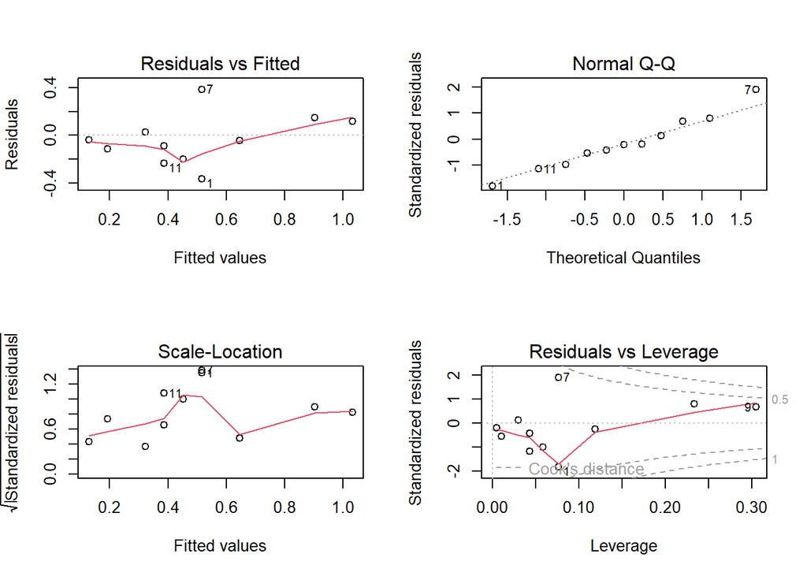

```r
par(mfrow = c(2, 2))
plot(m2)
```

prvy graf, nahodnost rezidui, mali by byt nahodne rozdelene okolo priamky y = 0 Druhy graf je o normalite rezidui, idealne by mali lezat na naznacenej priamke, 1, 7, 11 Treti graf - konstantnost rozptylu, homoskedasticita, oznacene body 1, 7, 11 tiez budeme testovat vhodnym testom Detekovanie vplyvnych bodov regresie (1, 7, 9) Rataju sa aj ine rezidua - standardizovane, predikovane, studentizovane

```r
residuals(m2)
```

```
##           1           2           3           4           5           6
## -0.36604291 -0.11351609 -0.08703218 -0.20153754 -0.04505364  0.14692491
##           7           8           9          10          11
##  0.38395709 -0.03901073  0.11791418  0.02747318 -0.23703218
```

```r
rstandard(m2)
```

```
##          1          2          3          4          5          6          7
## -1.8188309 -0.5450415 -0.4248477 -0.9918673 -0.2292550  0.8014956  1.9078447
##          8          9         10         11
## -0.1867463  0.6755274  0.1332011 -1.1570729
```

```r
rstudent(m2)
```

```
##          1          2          3          4          5          6          7
## -2.1093096 -0.5249275 -0.4067333 -0.9909759 -0.2180642  0.7860316  2.2695059
##          8          9         10         11
## -0.1774728  0.6560043  0.1264779 -1.1794876
```

ideme overovat postupne vlastnosti rezidui Nahodnost

```r
library(randtests)
turning.point.test(m2$residuals)
```

```
##
##  Turning Point Test
##
## data:  m2$residuals
## statistic = -0.78246, n = 11, p-value = 0.4339
## alternative hypothesis: non randomness
```

Su nahodne, lebo p hodnota > 0.05 test autokorelovanosti

```r
library(car)
durbinWatsonTest(m2)
```

```
##  lag Autocorrelation D-W Statistic p-value
##    1       0.2394556      1.087372   0.102
##  Alternative hypothesis: rho != 0
```

Nulova hypoteza je, ze su nekorelovane, Phodnota > 0.05 takze nezamietame nulovu hypotezu. Ideme overit ci su data normalne rozdelene s nulovou strednou hodnotou

```r
library(nortest)
shapiro.test(m2$residuals)
```

```
##
##  Shapiro-Wilk normality test
##
## data:  m2$residuals
## W = 0.97766, p-value = 0.9517
```

Nezamietam hypotezu o normalite rezidui

```r
t.test(m2$residuals)
```

```
##
##  One Sample t-test
##
## data:  m2$residuals
## t = -0.60542, df = 10, p-value = 0.5584
## alternative hypothesis: true mean is not equal to 0
## 95 percent confidence interval:
##  -0.1757068  0.1006239
## sample estimates:
##   mean of x
## -0.03754145
```

p hodnota > 0.05, teda nezamietame hypotezu o nulovosti strednej hodnoty. Ostava este overit konstantnost rozptylu, homoskedasticitu

```r
library(lmtest)
gqtest(odchylka~0+doba)
```

```
##
##  Goldfeld-Quandt test
##
## data:  odchylka ~ 0 + doba
## GQ = 2.0353, df1 = 5, df2 = 4, p-value = 0.2554
## alternative hypothesis: variance increases from segment 1 to 2
```

P-hodnota > 0.05, nezamietame hypotezu o konstantnosti rozptylu rezidui # Vplyvne body regresie napr podla Cook distancies, vacsie ako 1 vplyvny bod

```r
cooks.distance(m2) # nie su vplyvne body
```

```
##            1            2            3            4            5            6
## 0.2731888131 0.0032212433 0.0080919556 0.0610205576 0.0071120229 0.1958156253
##            7            8            9           10           11
## 0.3005829234 0.0001670619 0.2003813509 0.0005449184 0.0600217127
```

```r
library(olsrr)
```

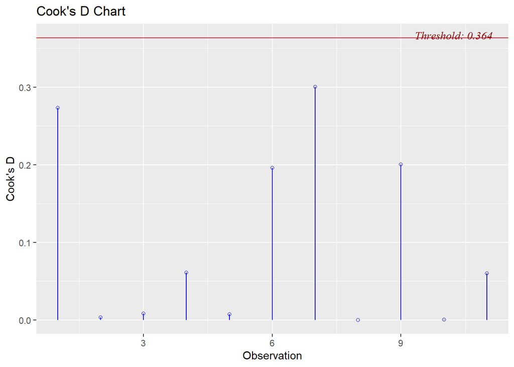

```r
ols_plot_cooksd_chart(m2) # nie su vplyvne body
```

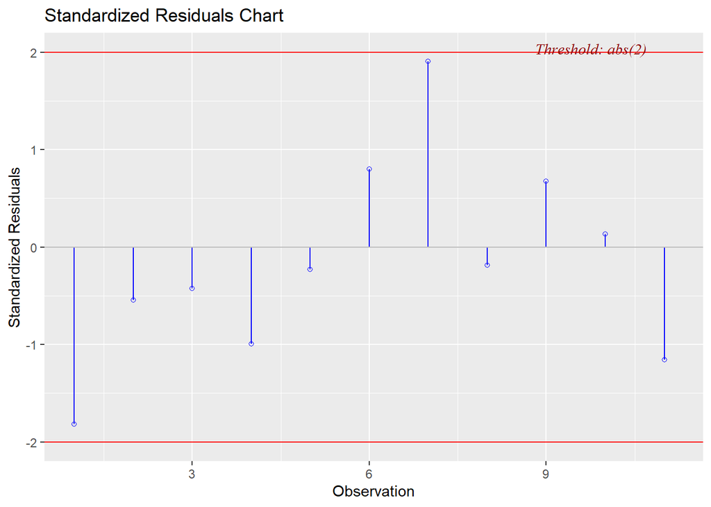

```r
ols_plot_resid_stand(m2) # nie su vybocujuce
```

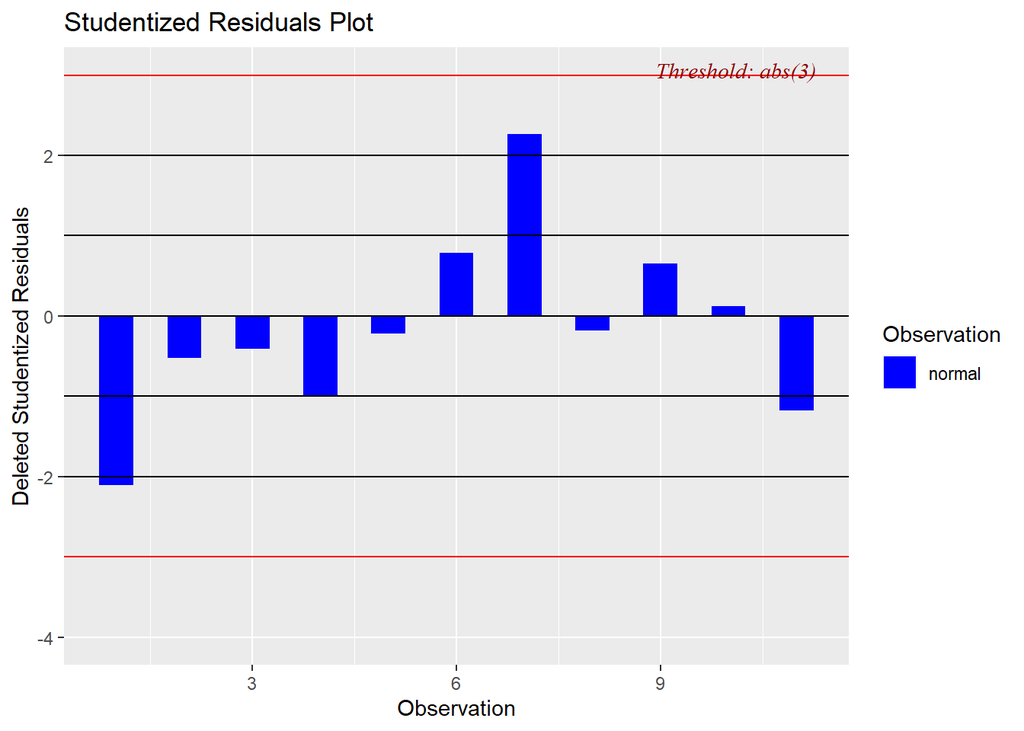

```r
ols_plot_resid_stud(m2) # nie su vybocujuce
```

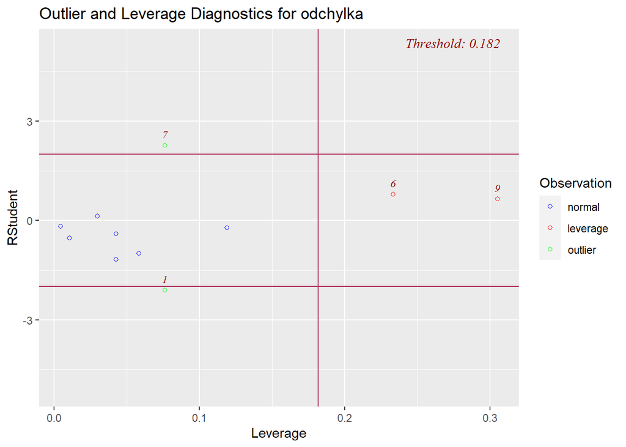

```r
ols_plot_resid_lev(m2) # outliers 1, 7, lever. 6, 9
```

meranie 7 sa casto vyskytuje ako problemove, je tam najvacsia hodnota rezidua, skusime ju vyhodit, prepocitat regresiu, vyhodnotit kvalitu s tym ale opatrne, ak mame maly pocet merani

```r
odchylka1 <- odchylka[-c(7)]
doba1 <- doba[-c(7)]
m3 <- lm(odchylka1~0+doba1)
AIC(m1, m2, m3)
```

```
##    df        AIC
## m1  3 -0.1843072
## m2  2 -0.2293099
## m3  2 -3.4170902
```

```r
summary(m3)
```

```
##
## Call:
## lm(formula = odchylka1 ~ 0 + doba1)
##
## Residuals:
##      Min       1Q   Median       3Q      Max
## -0.33434 -0.15575 -0.04717  0.03411  0.20241
##
## Coefficients:
##       Estimate Std. Error t value Pr(>|t|)
## doba1 0.060542   0.006323   9.575 5.13e-06 ***
## ---
## Signif. codes:  0 '***' 0.001 '**' 0.01 '*' 0.05 '.' 0.1 ' ' 1
##
## Residual standard error: 0.176 on 9 degrees of freedom
## Multiple R-squared:  0.9106, Adjusted R-squared:  0.9007
## F-statistic: 91.68 on 1 and 9 DF,  p-value: 5.132e-06
```

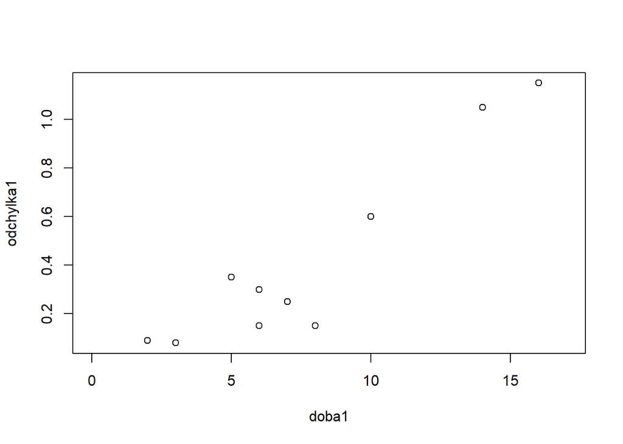

```r
plot(doba1, odchylka1, xlim=c(0, 17))
```

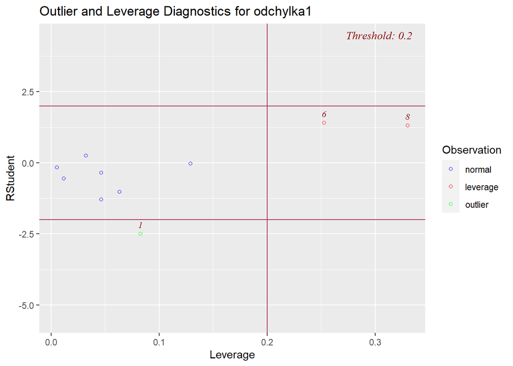

```r
#abline(m3, col='red')
ols_plot_resid_lev(m3)
```